# 811 Visualizations

Brandan P Buck

3/2/2020

```r
library(dplyr)
```

```r
library(ggplot2)
library(ggExtra)
library(jpeg)
library(knitr)
library(pals)
library(grid)
library(tidyverse)
library(RColorBrewer)
library(plotly)
key_votes<- read.csv("C:/Users/bpbuc/Documents/Brandan's Stuff/_PhD Stuff/Dissertation Research/new_digital_project/clean_data/key_votes_new.csv")

key_votes_79_88_list<- read.csv("C:/Users/bpbuc/Documents/Brandan's Stuff/_PhD Stuff/Dissertation Research/new_digital_project/clean_data/key_votes_79_88_list.csv")

Hall_all_members<- read.csv("C:/Users/bpbuc/Documents/Brandan's Stuff/_PhD Stuff/Dissertation Research/new_digital_project/raw_data/HSall_members.csv")
```

## The Data

The cleaning process of this data can be found within the “cleaning” folder of the project.

## Plots I intend to use in the 811 paper

I intend to use the following two plots to orientate the reader of my 811 paper. The narrative begins in the 85th congress and ends in the 90th, therefore the plots are useful to provide the backstory and illustrate the political decline of the Old Isolationist right. The plots also illustrate the relative support/opposition to the three categories of legislation and the gaps between them. The scatterplot makes the argument that foreign aid spending enjoyed relatively weak support on the right…in both parties, but primarily in the GOP. Lastly, the plots, particularly the line plot will set up the latter narrative/plots which concern the Republican revolt on foreign aid.

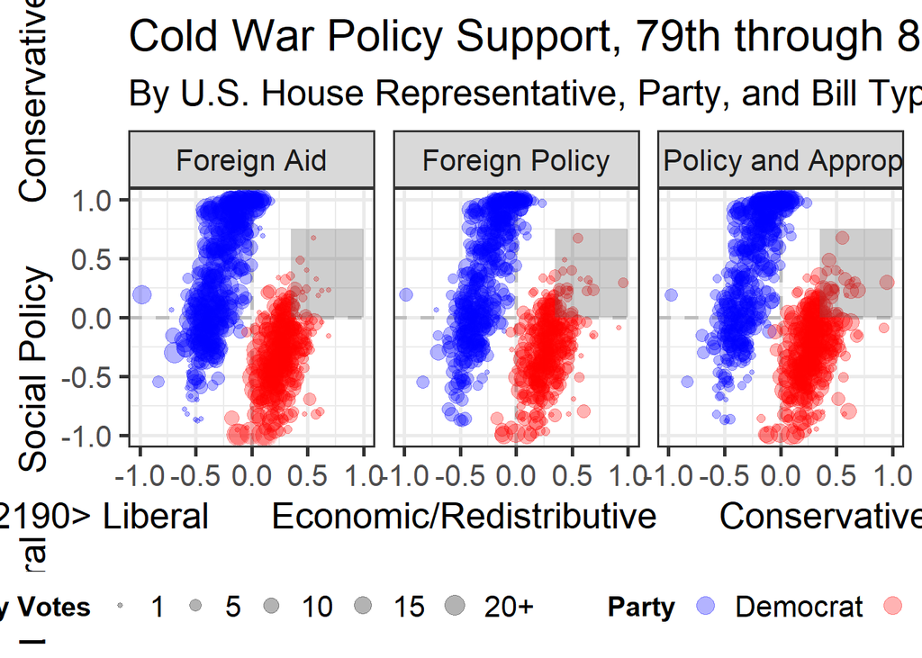

```r
label<- c(econ = "Foreign Aid", gov = "Foreign Policy", mil = "Military Policy and Appropriations")
bb <- c(1, 5, 10, 15, 20)
ll <- c("1", "5", "10", "15", "20+")

key_votes %>%
  filter(congress < 84) %>%
  filter(party_code == "Democrat" |
           party_code ==  "Republican") %>%
  filter(cohort == "int") %>%
  group_by(cohort, party_code, nominate_dim1, nominate_dim2, type) %>%
  summarize(num = n()) %>%
  ggplot(aes(x= nominate_dim1, y= nominate_dim2, size = num, color = party_code)) +
  facet_wrap(~type, labeller=labeller(type = label)) +
  xlim(-1,1) + ylim(-1, 1) +
  geom_hline(yintercept = 0, linetype="dashed", color = "grey", size = 1) +
  geom_vline(xintercept = 0, linetype="dashed", color = "grey", size = 1) +
  geom_point(alpha = .3) +
  annotate("rect", xmin = 0.35, xmax = 1, ymin = 0, ymax = 0.75,
           alpha = .3) +
  labs(title = "Cold War Policy Support, 79th through 83rd Congress ",
       subtitle = "By U.S. House Representative, Party, and Bill Type ",
       color = "Party",
       x = "← Liberal      Economic/Redistributive      Conservative →",
       y = "← Liberal      Social Policy      Conservative →") +
  scale_color_manual(labels = c("Democrat", "Republican"),
                     values = c("blue", "red")) +
  scale_size_continuous(name = "Yay Votes",
                        breaks = bb,
                        labels = ll) +
  theme_bw(base_size = 20) +
  theme(legend.position="bottom", legend.box = "horizontal",
        legend.title = element_text(size=15, color = "Black", face="bold")) +
  guides(color = guide_legend(override.aes = list(size=4.5)))
```

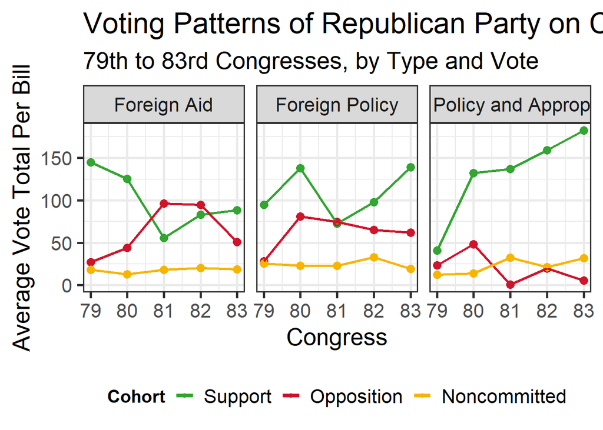

```r
bill_total<- key_votes_79_88_list %>%
  group_by(congress, type) %>%
  summarize(number = n())

pal<- c("#33a532", "#cf142b", "#f7b500")

key_votes %>%
  filter(party_code == "Republican") %>%
  filter(congress < 84) %>%
  filter(reverse_vote == "N") %>%
  group_by(cohort, congress, type) %>%
  summarize(vote = n()) %>%
  left_join(bill_total, by = c("congress", "type")) %>%
  mutate(avg = vote / number) %>%
  ggplot(aes(x= congress, y= avg, color = cohort)) + geom_point(size= 3) + geom_line(size= 1) +
  facet_wrap(~type, labeller=labeller(type = label)) +
  labs(title = "Voting Patterns of Republican Party on Cold War Policy",
       subtitle = "79th to 83rd Congresses, by Type and Vote",
       color = "Cohort",
       x = "Congress",
       y = "Average Vote Total Per Bill") +
  scale_color_manual(values = pal,
                     labels = c("Support", "Opposition", "Noncommitted")) +
  theme_bw(base_size = 20) +
  theme(legend.position="bottom", legend.box = "horizontal",
        legend.title = element_text(size=15, color = "Black", face="bold")) +
  guides(color = guide_legend(override.aes = list(size=1.5)))
```

Vote on the Eisenhower Doctrine (85 H.J.Res. 117). One of the key foreign policy votes prior to the Gulf of Tonkin Resolution. I intend to use this plot to argue that under certain conditions, the Old Isolationists were still prone to vote against measures which vested power within the executive, even, in as in this case if POTUS is of the same party. The plot also illustrates that Republican opposition, was, with a few exceptions clustered on the party’s right wing.

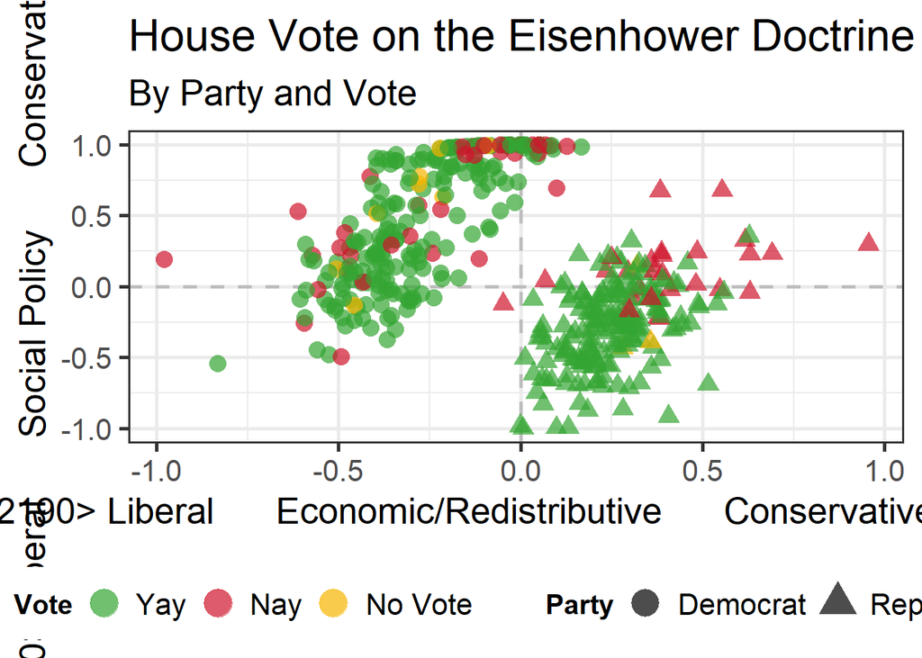

```r
key_votes %>%
  filter(congress == "85") %>%
  filter(rollnumber == "3") %>%
  ggplot(aes(x= nominate_dim1, y= nominate_dim2, color = cohort, shape = party_code)) +
  geom_hline(yintercept = 0, linetype="dashed", color = "grey", size = 1) +
  geom_vline(xintercept = 0, linetype="dashed", color = "grey", size = 1) +
  geom_point(size = 4, alpha = .7) +
  labs(title = "House Vote on the Eisenhower Doctrine (85 H.J.Res. 117)",
       subtitle = "By Party and Vote",
       color = "Vote",
       shape = "Party",
       x = "← Liberal      Economic/Redistributive      Conservative→",
       y = "← Liberal      Social Policy      Conservative→") +
  scale_color_manual(labels = c("Yay", "Nay", "No Vote"),
                     values = pal)+
  theme_bw(base_size = 20) +
  theme(legend.position="bottom", legend.box = "horizontal",
        legend.title = element_text(size=15, color = "Black", face="bold")) +
  guides(color = guide_legend(override.aes = list(size=7)),
         shape = guide_legend(override.aes = list(size=7)))
```

This plot of the voting pattern on the Foreign Assistance Act of 1961 (87 H.R. 8400) is useful because it is a pivotal piece of legislation that enables the U.S. governments nonmilitary aid throughout the 1960s. The plot establishes rough base line which shows the majority of opposition existed on the right. The plot is also useful when juxtaposed with…

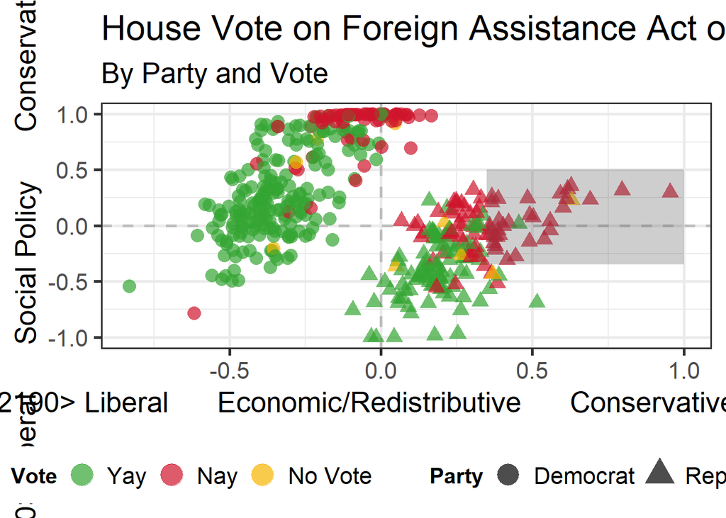

```r
key_votes %>%
  filter(congress == "87") %>%
  filter(bill_no == "HR8400") %>%
  ggplot(aes(x= nominate_dim1, y= nominate_dim2, color = cohort, shape = party_code)) +
  geom_hline(yintercept = 0, linetype="dashed", color = "grey", size = 1) +
  geom_vline(xintercept = 0, linetype="dashed", color = "grey", size = 1) +
  geom_point(size = 4, alpha = .7) +
    annotate("rect", xmin = 0.35, xmax = 1, ymin = -0.35, ymax = 0.5,
           alpha = .3) +
  labs(title = "House Vote on Foreign Assistance Act of 1961 (87 H.R. 8400)",
       subtitle = "By Party and Vote",
       color = "Vote",
       shape = "Party",
       x = "← Liberal      Economic/Redistributive      Conservative→",
       y = "← Liberal      Social Policy      Conservative→") +
  scale_color_manual(labels = c("Yay", "Nay", "No Vote"),
                     values = pal)+
  theme_bw(base_size = 20) +
  theme(legend.position="bottom", legend.box = "horizontal",
        legend.title = element_text(size=15, color = "Black", face="bold")) +
  guides(color = guide_legend(override.aes = list(size=7)),
         shape = guide_legend(override.aes = list(size=7)))
```

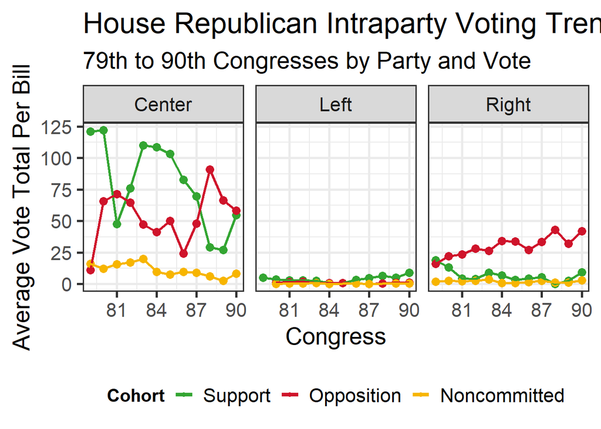

```r
econ_year<- key_votes_79_88_list %>%
  group_by(congress, type) %>%
  filter(type == "econ") %>%
  summarize(number = n())

key_votes %>%
  filter(party_code ==  "Republican") %>%
  filter(type == "econ") %>%
  filter(wing != "UNK") %>%
  group_by(cohort, congress, wing) %>%
  summarize(vote = n()) %>%
  left_join(econ_year, by = "congress") %>%
  mutate(avg = vote / number) %>%
  ggplot(aes(x= congress, y= avg, color = cohort)) + geom_point(size= 3) + geom_line(size= 1) +
  facet_wrap(~wing) +
  labs(title = "House Republican Intraparty Voting Trends on Foreign Aid",
       subtitle = "79th to 90th Congresses by Party and Vote",
       color = "Cohort",
       x = "Congress",
       y = "Average Vote Total Per Bill") +
  scale_color_manual(labels = c("Support", "Opposition", "Noncommitted"),
                     values = pal)+
    theme_bw(base_size = 20) +
  theme(legend.position="bottom", legend.box = "horizontal",
        legend.title = element_text(size=15, color = "Black", face="bold")) +
  guides(color = guide_legend(override.aes = list(size=1.5)))
```

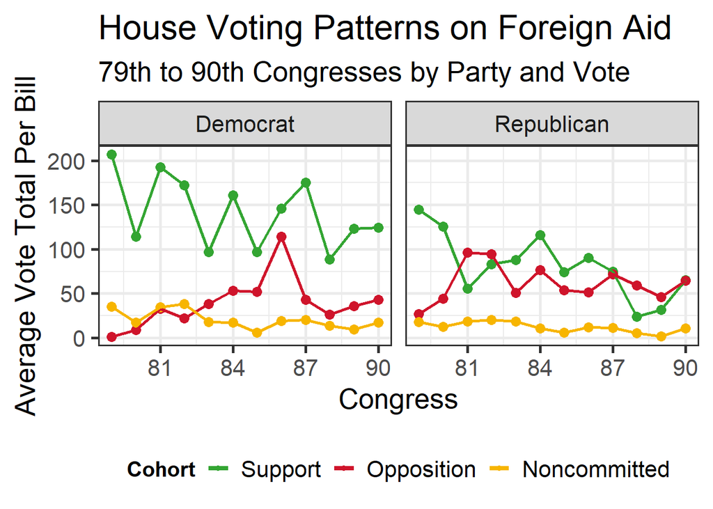

```r
bill_total<- key_votes_79_88_list %>%
  group_by(congress, type) %>%
  summarize(number = n())

pal<- c("#33a532", "#cf142b", "#f7b500")

key_votes %>%
  filter(party_code == "Democrat" |
         party_code == "Republican") %>%
  filter(type == "econ") %>%
  filter(reverse_vote == "N") %>%
  group_by(cohort, congress, party_code, type) %>%
  summarize(vote = n()) %>%
  left_join(bill_total, by = c("congress", "type")) %>%
  mutate(avg = vote / number) %>%
  ggplot(aes(x= congress, y= avg, color = cohort)) + geom_point(size= 3) + geom_line(size= 1) +
  facet_wrap(~party_code, labeller=labeller(type = label)) +
  labs(title = "House Voting Patterns on Foreign Aid ",
       subtitle = "79th to 90th Congresses by Party and Vote",
       color = "Cohort",
       x = "Congress",
       y = "Average Vote Total Per Bill") +
  scale_color_manual(values = pal,
                     labels = c("Support", "Opposition", "Noncommitted")) +
  theme_bw(base_size = 20) +
  theme(legend.position="bottom", legend.box = "horizontal",
        legend.title = element_text(size=15, color = "Black", face="bold")) +
  guides(color = guide_legend(override.aes = list(size=1.5)))
```

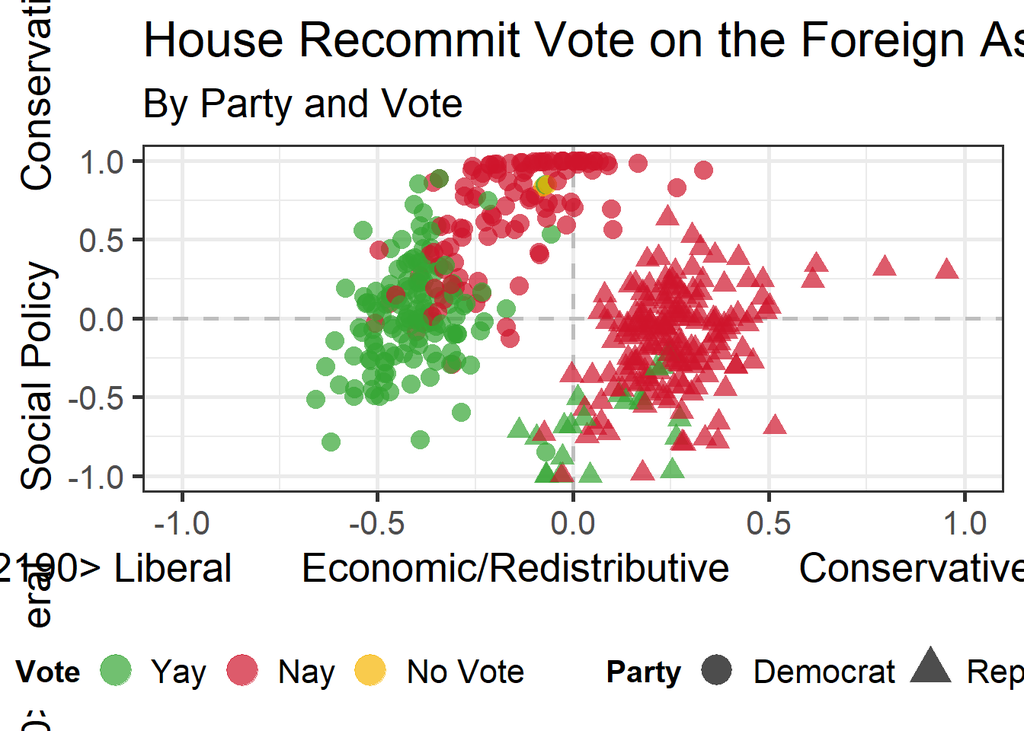

```r
key_votes %>%
  filter(congress == "90") %>%
  filter(rollnumber == "390") %>%
  ggplot(aes(x= nominate_dim1, y= nominate_dim2, color = cohort, shape = party_code)) +
  xlim(-1,1) + ylim(-1, 1) +
  geom_hline(yintercept = 0, linetype="dashed", color = "grey", size = 1) +
  geom_vline(xintercept = 0, linetype="dashed", color = "grey", size = 1) +
  geom_point(size = 4, alpha = .7) +
  labs(title = "House Recommit Vote on the Foreign Assistance Act of 1968 (90 H.R. 15263)",
       subtitle = "By Party and Vote",
       color = "Vote",
       shape = "Party",
       x = "← Liberal      Economic/Redistributive      Conservative →",
       y = "← Liberal      Social Policy      Conservative →") +
  scale_color_manual(labels = c("Yay", "Nay", "No Vote"),
                     values = pal) +
  theme_bw(base_size = 20) +
  theme(legend.position="bottom", legend.box = "horizontal",
        legend.title = element_text(size=15, color = "Black", face="bold")) +
  guides(color = guide_legend(override.aes = list(size=7)),
         shape = guide_legend(override.aes = list(size=7)))
```

Two months after the Foreign Assistance Act of 1968 vote, congress voted to approve the Foreign Military Sales Act (https://voteview.com/rollcall/RH0900419). The act, as the title indicates made available military aid to a host of countries. Because it pertained to military rather than civilian aid, it enjoyed considerably more support. The bill also, ironically, contained provisions for arms control, which likely gained it some support. The act passed the house by a vote of 313-29 in the House and passed by voice vote in the Senate.

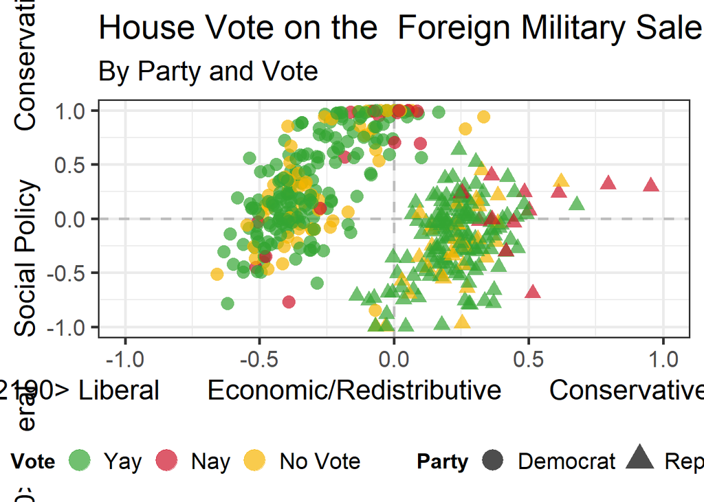

```r
key_votes %>%
  filter(congress == "90") %>%
  filter(rollnumber == "419") %>%
  ggplot(aes(x= nominate_dim1, y= nominate_dim2, color = cohort, shape = party_code)) +
  xlim(-1,1) + ylim(-1, 1) +
  geom_hline(yintercept = 0, linetype="dashed", color = "grey", size = 1) +
  geom_vline(xintercept = 0, linetype="dashed", color = "grey", size = 1) +
  geom_point(size = 4, alpha = .7) +
  labs(title = "House Vote on the  Foreign Military Sales Act (90 H.R. 15681)",
       subtitle = "By Party and Vote",
       color = "Vote",
       shape = "Party",
       x = "← Liberal      Economic/Redistributive      Conservative →",
       y = "← Liberal      Social Policy      Conservative →") +
  scale_color_manual(labels = c("Yay", "Nay", "No Vote"),
                     values = pal) +
  theme_bw(base_size = 20) +
  theme(legend.position="bottom", legend.box = "horizontal",
        legend.title = element_text(size=15, color = "Black", face="bold")) +
  guides(color = guide_legend(override.aes = list(size=1.5))) +
  theme_bw(base_size = 20) +
  theme(legend.position="bottom", legend.box = "horizontal",
        legend.title = element_text(size=15, color = "Black", face="bold")) +
  guides(color = guide_legend(override.aes = list(size=7)),
         shape = guide_legend(override.aes = list(size=7)))
```